# Pertemuan 2 - Regresi

Dewi Kunthi Siswati Suryo

2023-09-10

## Pemanggilan *Packages*

```r
library(forecast)
```

```r
library(graphics)
library(TTR)
library(TSA)
library(rio)
library(ggplot2)
library(lmtest)
library(orcutt)
library(HoRM)
library(corrplot)
library(RColorBrewer)
library(scales)
library(dplyr)
library(knitr)
```

## Input Data

```r
data <- import("https://raw.githubusercontent.com/dewidesis/MPDW-Prak/main/Pertemuan%202/data_wine.csv")
View(data)

flip <- function(data){
  new <- data[rev(rownames(data)),]
  rownames(new) <- NULL
  new
}

data <- flip(data)
View(data)
```

## Eksplorasi Data

Sebelum melakukan regresi, akan diperlihatkan *plot time-series*.

```r
# Eksplorasi Data
summary(data)
```

```
##      Tahun          Panen          Produksi          Harga
##  Min.   :1980   Min.   :  501   Min.   :  4307   Min.   :211.0
##  1st Qu.:1990   1st Qu.: 1374   1st Qu.:  9664   1st Qu.:362.0
##  Median :2000   Median : 8704   Median : 60739   Median :560.6
##  Mean   :2000   Mean   : 7646   Mean   : 53633   Mean   :536.6
##  3rd Qu.:2010   3rd Qu.:12002   3rd Qu.: 84853   3rd Qu.:692.7
##  Max.   :2020   Max.   :19200   Max.   :150000   Max.   :865.4
```

```r
# Membuat Matriks Korelasi
matriks <- cor(data)
matriks
```

```
##              Tahun     Panen  Produksi     Harga
## Tahun    1.0000000 0.9663489 0.9560102 0.8521437
## Panen    0.9663489 1.0000000 0.9898948 0.8345795
## Produksi 0.9560102 0.9898948 1.0000000 0.8108177
## Harga    0.8521437 0.8345795 0.8108177 1.0000000
```

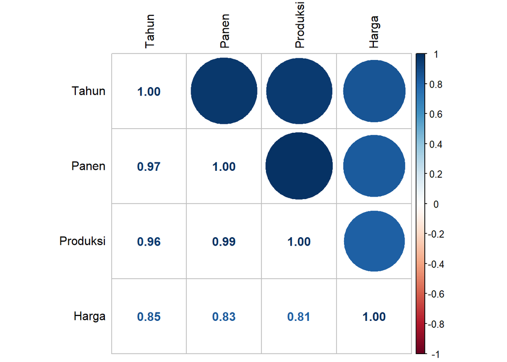

```r
corrplot.mixed(matriks, upper = 'circle', lower = 'number', order = "original",
               tl.col="black", tl.pos = "lt",diag = 'l',
               number.digits=2, number.cex=1)
```

Matriks korelasi di atas menunjukkan hubungan positif yang kuat antar semua peubah penjelas dengan peubah respon. Peubah respon : Harga Peubah penjelas : Tahun, Panen, Produksi

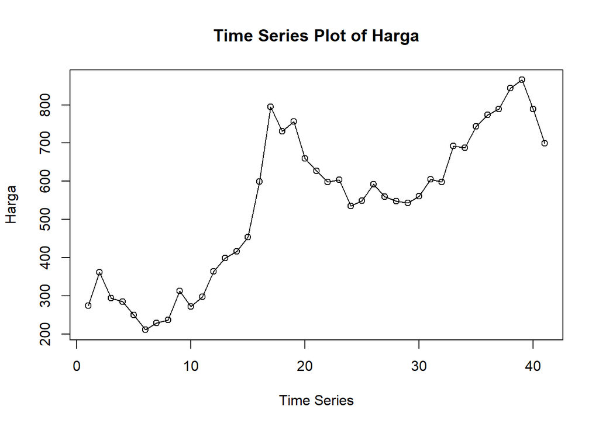

```r
#Membuat Objek Time Series
data.ts <- ts(data$Harga)

#Plot Time Series
ts.plot(data.ts, xlab = "Time Series",
        ylab = "Harga",
        main = "Time Series Plot of Harga")
points(data.ts)
```

Dapat dilihat pada time series plot di atas bahwa data tersebut berpola tren.

## Regresi

```r
#Pembuatan Model Regresi
#Model Regresi
model <- lm(Harga~Tahun+Panen+Produksi, data=data)
summary(model)
```

```
##
## Call:
## lm(formula = Harga ~ Tahun + Panen + Produksi, data = data)
##
## Residuals:
##     Min      1Q  Median      3Q     Max
## -136.54  -84.19  -12.62   34.30  286.14
##
## Coefficients:
##               Estimate Std. Error t value Pr(>|t|)
## (Intercept) -2.195e+04  1.063e+04  -2.064   0.0461 *
## Tahun        1.122e+01  5.358e+00   2.093   0.0432 *
## Panen        3.139e-02  2.331e-02   1.347   0.1863
## Produksi    -3.525e-03  2.810e-03  -1.254   0.2176
## ---
## Signif. codes:  0 '***' 0.001 '**' 0.01 '*' 0.05 '.' 0.1 ' ' 1
##
## Residual standard error: 104.4 on 37 degrees of freedom
## Multiple R-squared:  0.7391, Adjusted R-squared:  0.718
## F-statistic: 34.94 on 3 and 37 DF,  p-value: 6.878e-11
```

```r
#Melakukan uji terhadap sisaan
#Sisaan dan Fitted Value
sisaan <- residuals(model)
fittedvalue <- predict(model)
```

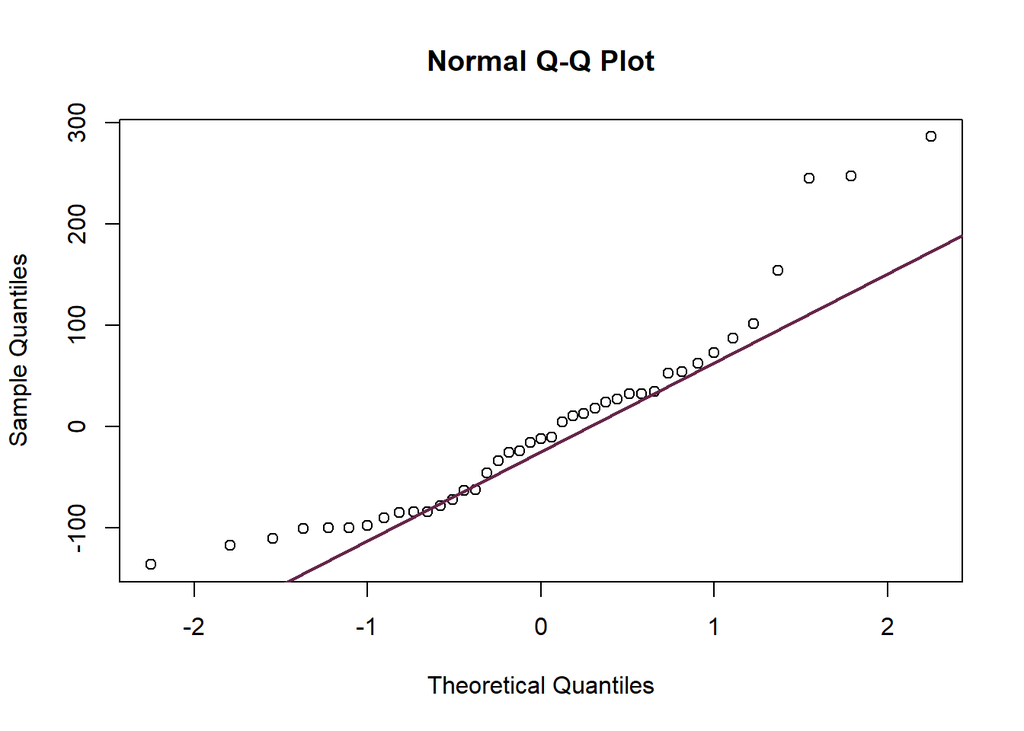

```r
#Diagnostik dengan Eksploratif
qqnorm(sisaan)

#Normal Q-Q Plot
qqline(sisaan, col = "#662549", lwd = 2)
```

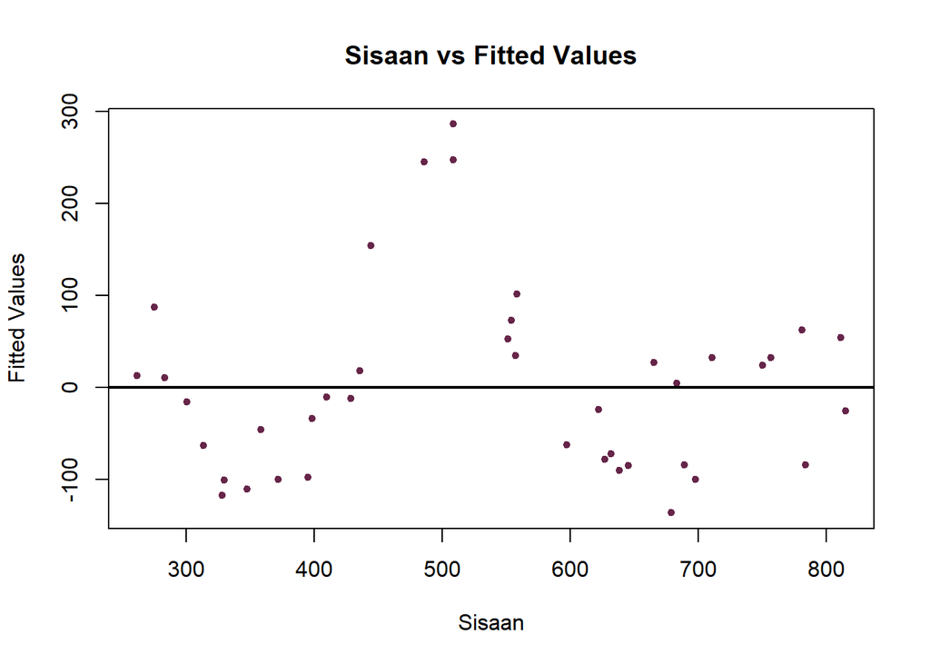

```r
plot(fittedvalue, sisaan, col = "#662549", pch = 20, xlab = "Sisaan", ylab = "Fitted Values", main = "Sisaan vs Fitted Values")
abline(a = 0, b = 0, lwd = 2)
```

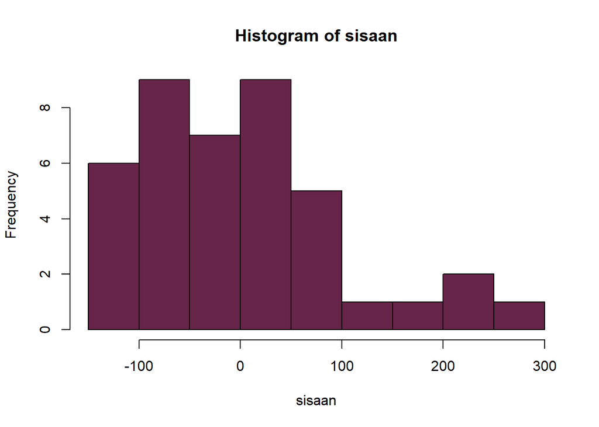

```r
#Histogram Sisaan
hist(sisaan, col = "#662549")
```

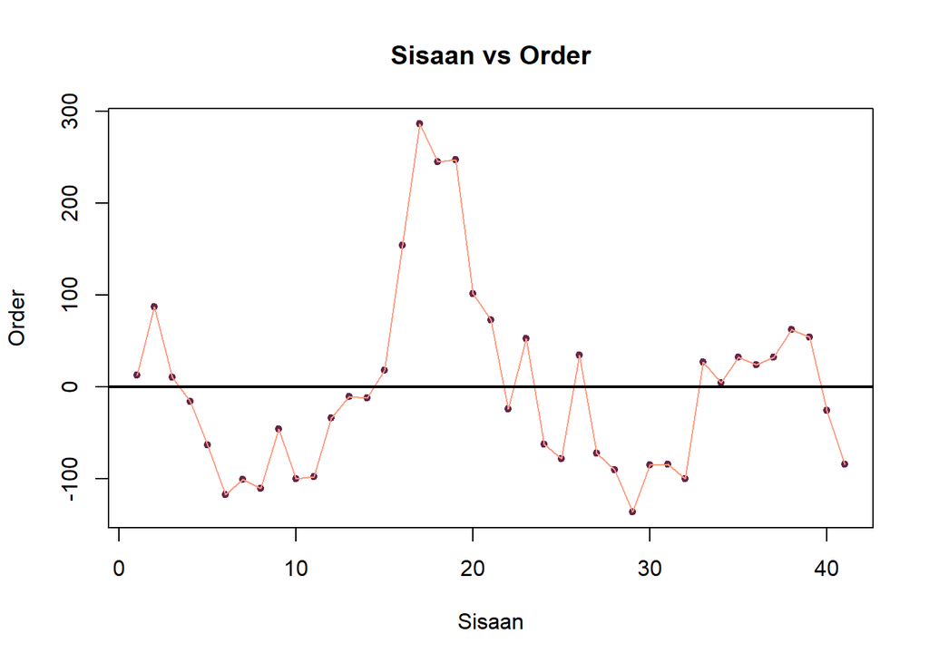

```r
plot(seq(1,41,1), sisaan, col = "#662549", pch = 20, xlab = "Sisaan", ylab = "Order", main = "Sisaan vs Order")

lines(seq(1,41,1), sisaan, col = "#FF9B82")
abline(a = 0, b = 0, lwd = 2)
```

Berdasarkan hasil Normal Q-Q Plot menunjukkan bahwa sisaan cenderung menyebar normal. Berdasarkan histogram sisaan terlihat bahwa sisaan menyebar ke kanan (positive skewness). Berdasarkan Plot sisaan vs Order, terlihat bahwa sisaan terdapat pola naik turun. Hal tersebut menunjukkan adanya autokorelasi karena ada pola antar sisaan.

## Uji Formal Normality Test

H0 : sisaan mengikuti sebaran normal H1 : Sisaan tidak mengikuti sebaran normal

```r
ks.test(sisaan, "pnorm", mean=mean(sisaan), sd=sd(sisaan))
```

```
##
##  Exact one-sample Kolmogorov-Smirnov test
##
## data:  sisaan
## D = 0.12241, p-value = 0.5306
## alternative hypothesis: two-sided
```

Berdasarkan tes normalitas menggunakan Kolmogrov-Smirnov Test didapatkan
$$p value > \alpha$$
5% yang artinya sisaan menyebar normal (terima H0).

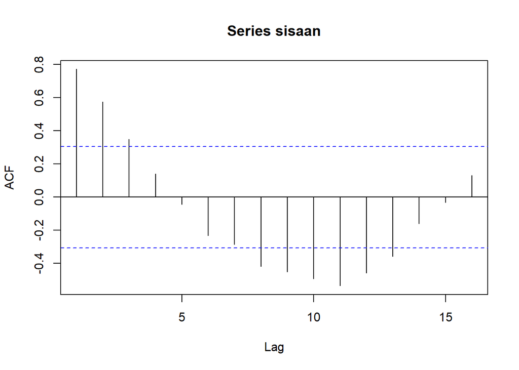

```r
#ACF dan PACF identifikasi autokorelasi
acf(sisaan)
```

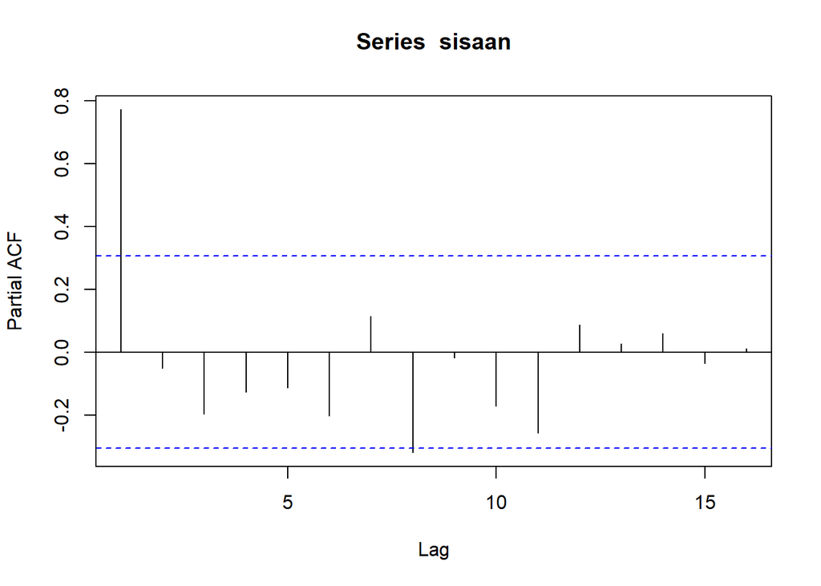

```r
pacf(sisaan)
```

Menurut Plot ACF dan PACF, terlihat bahwa terdapat garis melewati batas selang. Artinya, terdapat autokorelasi dalam model.